# hotel_booking

```python
import pandas as pd

df = pd.read_csv("hotel_bookings.csv")
```

<h1 id="1-carregamento-e-conhececimento-inicial-dos-dados">1 carregamento e conhececimento inicial dos dados</h1>

```python
df.head()
```

| Resort Hotel | 0 | 342 | 2015 | July | 27 | 1 | 0 | 0 | 2 | ... | No Deposit | NaN | NaN | 0 | Transient | 0.0 | 0 | 0 | Check-Out | 2015-07-01 |
| --- | --- | --- | --- | --- | --- | --- | --- | --- | --- | --- | --- | --- | --- | --- | --- | --- | --- | --- | --- | --- |
| Resort Hotel | 0 | 737 | 2015 | July | 27 | 1 | 0 | 0 | 2 | ... | No Deposit | NaN | NaN | 0 | Transient | 0.0 | 0 | 0 | Check-Out | 2015-07-01 |
| Resort Hotel | 0 | 7 | 2015 | July | 27 | 1 | 0 | 1 | 1 | ... | No Deposit | NaN | NaN | 0 | Transient | 75.0 | 0 | 0 | Check-Out | 2015-07-02 |
| Resort Hotel | 0 | 13 | 2015 | July | 27 | 1 | 0 | 1 | 1 | ... | No Deposit | 304.0 | NaN | 0 | Transient | 75.0 | 0 | 0 | Check-Out | 2015-07-02 |
| Resort Hotel | 0 | 14 | 2015 | July | 27 | 1 | 0 | 2 | 2 | ... | No Deposit | 240.0 | NaN | 0 | Transient | 98.0 | 0 | 1 | Check-Out | 2015-07-03 |

<p>5 rows × 32 columns</p>

```python
df.shape
```

```
(119390, 32)
```

```python
df.info()
```

```
<class 'pandas.DataFrame'>
RangeIndex: 119390 entries, 0 to 119389
Data columns (total 32 columns):
 #   Column                          Non-Null Count   Dtype
---  ------                          --------------   -----
 0   hotel                           119390 non-null  str
 1   is_canceled                     119390 non-null  int64
 2   lead_time                       119390 non-null  int64
 3   arrival_date_year               119390 non-null  int64
 4   arrival_date_month              119390 non-null  str
 5   arrival_date_week_number        119390 non-null  int64
 6   arrival_date_day_of_month       119390 non-null  int64
 7   stays_in_weekend_nights         119390 non-null  int64
 8   stays_in_week_nights            119390 non-null  int64
 9   adults                          119390 non-null  int64
```

[output cut: 24 more lines]

1. <p>Quantas instâncias e quantos atributos existem? o dataset possui 119390 instâncias e com 32 atributos cada</p>
2. <p>Quais atributos são numéricos e quais são categóricos? numéricos: is_canceled, lead_time, arrival_date_year, arrival_date_week_number, arrival_date_day_of_month, stays_in_weekend_nights, stays_in_week_nights, adults, children, babies, is_repeated_guest, previous_cancellations, previous_bookings_not_canceled, booking_changes, agent, company, days_in_waiting_list, adr, required_car_parking_spaces, total_of_special_requests</p> <p>categoricos: hotel, arrival_date_month, meal, country, market_segment, distribution_channel, reserved_room_type, assigned_room_type, deposit_type, customer_type, reservation_status, reservation_status_date.</p>
3. <p>Quais atributos são binários? tem 2 atributos binarios: is_canceled e is_repeated_guest</p>
4. <p>Quais atributos representam características da reserva, do cliente, da estadia e do hotel? Hotel: hotel. Reserva: is_canceled, lead_time, deposit_type, reservation_status, reservation_status_date, booking_changes, days_in_waiting_list, distribution_channel, market_segment. Cliente: adults, children, babies, customer_type, country, is_repeated_guest, previous_cancellations, previous_bookings_not_canceled. Estadia: stays_in_weekend_nights, stays_in_week_nights, arrival_date_year, arrival_date_month, arrival_date_week_number, arrival_date_day_of_month, meal, reserved_room_type, assigned_room_type, adr, required_car_parking_spaces, total_of_special_requests.</p>

<h1 id="2-qualidade-dos-dados">2 qualidade dos dados</h1>

```python
# ausentes
missing = df.isnull().sum()
missing[missing > 0]
print(missing[missing > 0])
```

```
children         4
country        488
agent        16340
company     112593
dtype: int64
```

```python
print(f"duplicados: {df.duplicated().sum()}")
```

```
duplicados: 31994
```

```python
df.nunique().sort_values()
```

```
hotel                                2
is_canceled                          2
is_repeated_guest                    2
arrival_date_year                    3
deposit_type                         3
reservation_status                   3
customer_type                        4
babies                               5
meal                                 5
distribution_channel                 5
children                             5
required_car_parking_spaces          5
total_of_special_requests            6
market_segment                       8
reserved_room_type                  10
arrival_date_month                  12
assigned_room_type                  12
adults                              14
previous_cancellations              15
stays_in_weekend_nights             17
booking_changes                     21
arrival_date_day_of_month           31
stays_in_week_nights                35
arrival_date_week_number            53
previous_bookings_not_canceled      73
days_in_waiting_list               128
country                            177
agent                              333
company                            352
lead_time                          479
reservation_status_date            926
adr                               8879
dtype: int64
```

<h1 id="3-estat%C3%ADstica-descritiva">3 estatística descritiva</h1>

```python
cols_destaque = [
    'lead_time', 'stays_in_weekend_nights', 'stays_in_week_nights',
    'adults', 'children', 'babies', 'previous_cancellations',
    'booking_changes', 'days_in_waiting_list', 'adr', 'total_of_special_requests'
]

desc = df[cols_destaque].describe().T

median = df[cols_destaque].median()
rangee = desc['max'] - desc['min']
irq = desc['75%'] - desc['25%']

desc['median'] = median
desc['range'] = rangee
desc['irq'] = irq

desc
```

| 119390.0 | 104.011416 | 106.863097 | 0.00 | 18.00 | 69.000 | 160.0 | 737.0 | 69.000 | 737.00 | 142.00 |
| --- | --- | --- | --- | --- | --- | --- | --- | --- | --- | --- |
| 119390.0 | 0.927599 | 0.998613 | 0.00 | 0.00 | 1.000 | 2.0 | 19.0 | 1.000 | 19.00 | 2.00 |
| 119390.0 | 2.500302 | 1.908286 | 0.00 | 1.00 | 2.000 | 3.0 | 50.0 | 2.000 | 50.00 | 2.00 |
| 119390.0 | 1.856403 | 0.579261 | 0.00 | 2.00 | 2.000 | 2.0 | 55.0 | 2.000 | 55.00 | 0.00 |
| 119386.0 | 0.103890 | 0.398561 | 0.00 | 0.00 | 0.000 | 0.0 | 10.0 | 0.000 | 10.00 | 0.00 |
| 119390.0 | 0.007949 | 0.097436 | 0.00 | 0.00 | 0.000 | 0.0 | 10.0 | 0.000 | 10.00 | 0.00 |
| 119390.0 | 0.087118 | 0.844336 | 0.00 | 0.00 | 0.000 | 0.0 | 26.0 | 0.000 | 26.00 | 0.00 |
| 119390.0 | 0.221124 | 0.652306 | 0.00 | 0.00 | 0.000 | 0.0 | 21.0 | 0.000 | 21.00 | 0.00 |
| 119390.0 | 2.321149 | 17.594721 | 0.00 | 0.00 | 0.000 | 0.0 | 391.0 | 0.000 | 391.00 | 0.00 |
| 119390.0 | 101.831122 | 50.535790 | -6.38 | 69.29 | 94.575 | 126.0 | 5400.0 | 94.575 | 5406.38 | 56.71 |
| 119390.0 | 0.571363 | 0.792798 | 0.00 | 0.00 | 0.000 | 1.0 | 5.0 | 0.000 | 5.00 | 1.00 |

<h1 id="4-visualizacoes-e-perguntas-de-investiga%C3%A7%C3%A3">4 visualizacoes e perguntas de investigaçã</h1>

```python
import seaborn as sns
import matplotlib.pyplot as plt

sns.set_theme(style="whitegrid", palette="muted")
```

<h2 id="grafico-1---distribuicao-do-tempo-de-antecedencia-das-reservas">grafico 1 - distribuicao do tempo de antecedencia das reservas</h2>

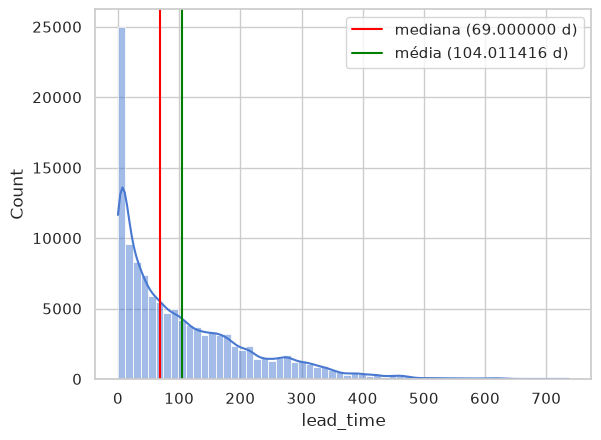

```python
sns.histplot(data=df, x=df["lead_time"], bins=60, kde=True)
plt.axvline(df['lead_time'].median(), color='red', label=f'mediana ({df["lead_time"].median():0f} d)')
plt.axvline(df['lead_time'].mean(), color='green', label=f'média ({df["lead_time"].mean():0f} d)')
plt.legend()
```

```python
lt = df["lead_time"]
print(lt.median())
print(lt.mean())
print(max(lt))
```

```
69.0
104.01141636652986
737
```

1. Em que faixa de antecedência está concentrada a maior parte das reservas? entre 0 e 30 dias, com pico no dia 0
2. A distribuição parece simétrica ou assimétrica? é assimétrica à direita (positiva), com média (104 dias) superior à mediana (69 dias)
3. Existe uma cauda longa para valores elevados? sim, estende-se até mais de 700 dias
4. Há indícios de valores extremos? sim, há várias reservas feitas entre 400 e 737 dias de antecedência
5. Há indícios de valores extremos? a maioria dos clientes planeja a curto prazo (menos de 2 meses), enquanto reservas longas são casos específicos

<h2 id="grafico-2--distribuicao-do-preco-medio-diario">grafico 2 -distribuicao do preco medio diario</h2>

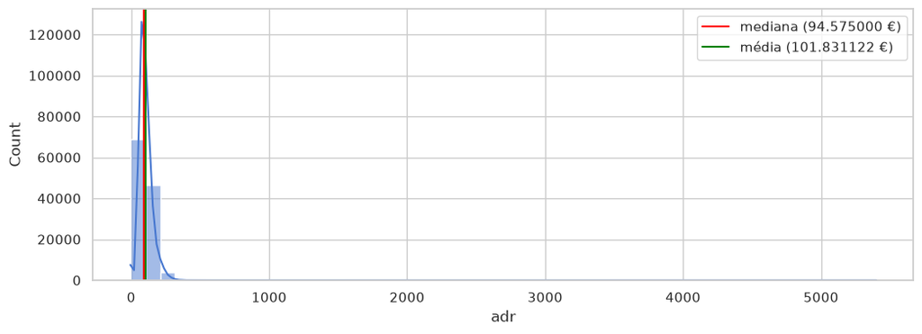

```python
plt.figure(figsize=(12, 4))
sns.histplot(data=df, x=df["adr"], bins=50, kde=True)
plt.axvline(df['adr'].median(), color='red', label=f'mediana ({df["adr"].median():1f} €)')
plt.axvline(df['adr'].mean(), color='green', label=f'média ({df["adr"].mean():1f} €)')
plt.legend()
```

```python
adr = df["adr"]
print(adr.median())
print(adr.mean())
print(max(adr))

adr_desc = adr.describe().T
# irq = adr_desc['75%'] - adr_desc['25%']
print(adr_desc['25%'])
print(adr_desc['75%'])
```

```
94.575
101.83112153446687
5400.0
69.29
126.0
```

1. Em qual faixa de preço está concentrada a maior parte das reservas? entre 69 € e 126 €, com mediana de 94,5 €
2. A distribuição apresenta assimetria? 7 sim, assimetria positiva à direita
3. Existem valores muito afastados da concentração principal? sim, há um valor isolado extremo de 5400 € e valores negativos/zerados
4. A média parece representar bem o preço típico? Compare com a mediana. a mediana 94,5 €) representa melhor o valor típico, pois a média (101,8 €) é puxada por preços altos
5. Que cuidados devem ser tomados ao utilizar ADR em análises posteriores? filtrar valores negativos/zerados e tratar o outlier de 5400 €

<h1 id="grafico-3---boxplot-do-adr-por-tipo-de-hotel">grafico 3 - boxplot do adr por tipo de hotel</h1>

```python
# snsboxplot(data=df, x='hotel', y='adr')
```

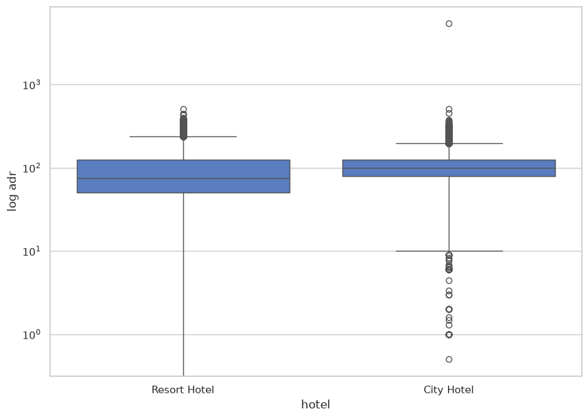

| 79330.0 | 105.304465 | 43.602954 | 0.00 | 79.2 | 99.9 | 126.0 | 5400.0 |
| --- | --- | --- | --- | --- | --- | --- | --- |
| 40060.0 | 94.952930 | 61.442418 | -6.38 | 50.0 | 75.0 | 125.0 | 508.0 |

```python
plt.figure(figsize=(10, 7))

sns.boxplot(data=df, x="hotel", y="adr")

plt.yscale("log")
plt.ylabel("log adr")

plt.show()

df.groupby('hotel')['adr'].describe()
```

1. Qual tipo de hotel apresenta maior mediana? o city hotel com 999 vs 750 do resort
2. Qual apresenta maior dispersão? o resort hotel irq de 750 vs 468 do city
3. Os intervalos interquartis são semelhantes? não, diferenca considerável
4. Há mais valores extremos em um dos grupos? sim, ambos tem, mas o city hotel tem mais outliers, incluindo o valor de 5400 €
5. Os preços dos dois hotéis apresentam comportamentos semelhantes? não, os precos apresentam uma notória diferença, o que reflete a dinâmica típica de cada mercado, hotelaria urbana x lazer

<h1 id="gr%C3%A1fico-4---cancelamentos-por-tipo-de-hotel">gráfico 4 - cancelamentos por tipo de hotel</h1>

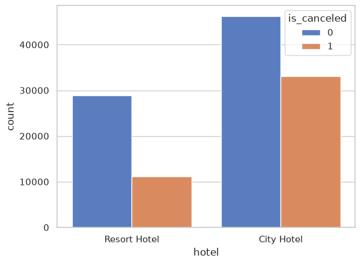

```python
sns.countplot(data=df, x="hotel", hue="is_canceled")
```

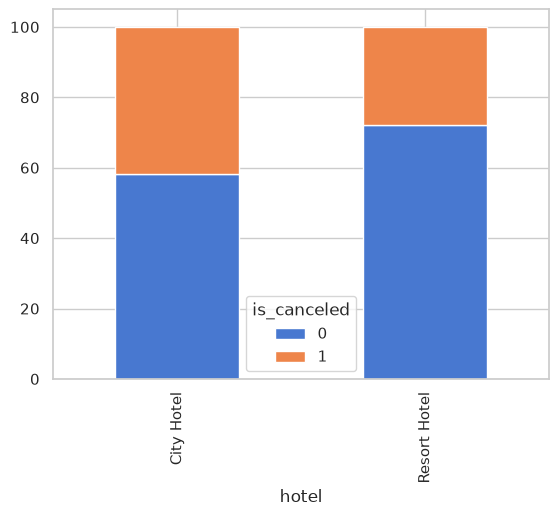

```python
df_pct = (
    pd.crosstab(df['hotel'], df['is_canceled'], normalize='index') * 100
)

df_pct.plot(kind='bar', stacked=True)
```

```python
print(df.groupby('hotel')['is_canceled'].mean())
print()
print(df.groupby('hotel')['is_canceled'].value_counts())
```

```
hotel
City Hotel      0.417270
Resort Hotel    0.277634
Name: is_canceled, dtype: float64

hotel         is_canceled
City Hotel    0              46228
              1              33102
Resort Hotel  0              28938
              1              11122
Name: count, dtype: int64
```

1. Qual hotel possui maior número absoluto de cancelamentos? o city hotel 33102 vs 11122 do resort
2. Qual apresenta maior proporção de cancelamentos? o city hotel 41,7% vs 27,8% do resort
3. Por que apenas o número absoluto pode levar a uma interpretação equivocada? porque o city hotel tem muito mais reservas no total, o percentual confirma que sua taxa de evasão relativa é realmente maior
4. O comportamento de cancelamento parece diferir entre os hotéis? sim, o cancelamento é significativamente mais frequente no City Hotel

<h1 id="gr%C3%A1fico-5---cancelamento-e-anteced%C3%AAncia-da-reserva">gráfico 5 - cancelamento e antecedência da reserva</h1>

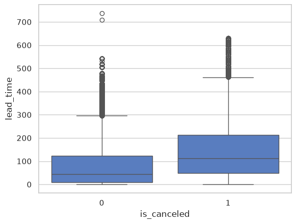

| 75166.0 | 79.984687 | 91.109888 | 0.0 | 9.0 | 45.0 | 124.0 | 737.0 |
| --- | --- | --- | --- | --- | --- | --- | --- |
| 44224.0 | 144.848815 | 118.624829 | 0.0 | 48.0 | 113.0 | 214.0 | 629.0 |

```python
sns.boxplot(data=df, x='is_canceled', y='lead_time')
plt.show()
df.groupby('is_canceled')['lead_time'].describe()
```

<h1 id="gr%C3%A1fico-6---demanda-ao-longo-do-ano-por-tipo-de-hotel">gráfico 6 - demanda ao longo do ano por tipo de hotel</h1>

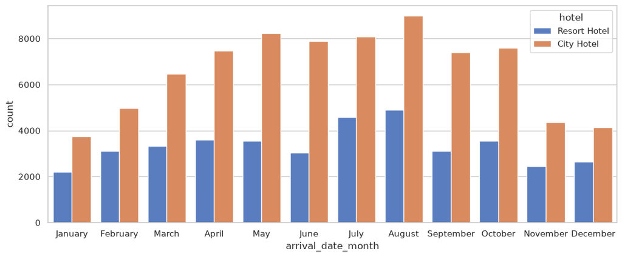

```python
meses = ['January', 'February', 'March', 'April', 'May', 'June', 'July', 'August', 'September', 'October', 'November', 'December']

plt.figure(figsize=(13,5))

sns.countplot(data=df, x='arrival_date_month', order=meses, hue='hotel')
```

1. Quais meses apresentam maior volume de reservas? julho e agosto
2. Existem períodos de baixa demanda? sim, novembro, dezembro e janeiro
3. O padrão é semelhante nos dois hotéis? sim no pico de verão, mas o city hotel mantém demanda alta também na primavera e outono
4. Em quais períodos as diferenças são mais evidentes? na primavera e outono (maio, junho, setembro, outubro), onde o city hotel supera amplamente o resort
5. Que implicação isso poderia ter para planejamento de capacidade ou preços? criar promoções no inverno, ou reduzir os funcionarios nesse periodo

<h1 id="gr%C3%A1fico---rela%C3%A7%C3%A3o-entre-anteced%C3%AAncia-e-pre%C3%A7o">gráfico - relação entre antecedência e preço</h1>

```
(-10.0, 500.0)
```

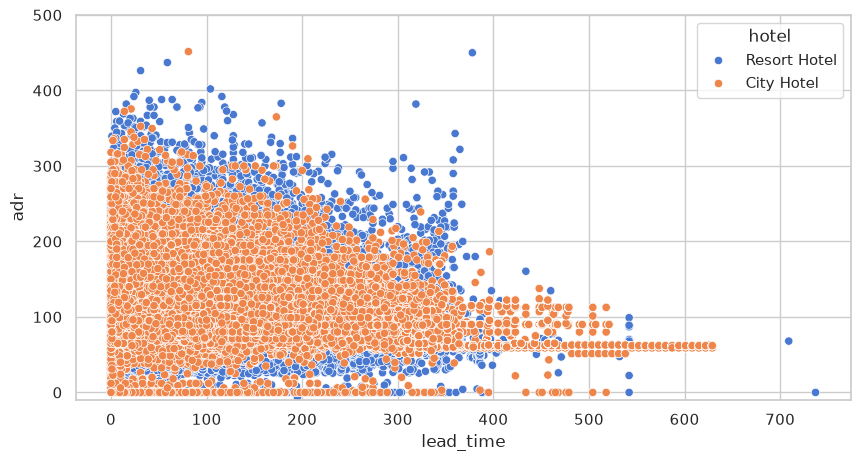

```python
plt.figure(figsize=(10,5))
sns.scatterplot(data=df, x='lead_time', y='adr', hue='hotel')
plt.ylim(-10,500)
```

1. É possível observar uma tendência entre antecedência e preço? não há tendência clara
2. A relação parece positiva, negativa ou inexistente? praticamente inexistente
3. O padrão é diferente entre os hotéis? não significativamente, ambos mantêm faixas de preços estáveis ao longo do tempo
4. Há regiões de grande concentração? sim, em lead time de 0 a 300 dias com ADR entre 50 € e 250 €
5. Existem pontos que fogem do padrão geral? sim, o valor isolado de 5400 € e reservas com mais de 500 dias

<h1 id="gr%C3%A1fico-8---rela%C3%A7%C3%A3o-entre-dura%C3%A7%C3%A3o-da-estadia-e-pre%C3%A7o">gráfico 8 - relação entre duração da estadia e preço</h1>

```
(0.0, 30.0)
```

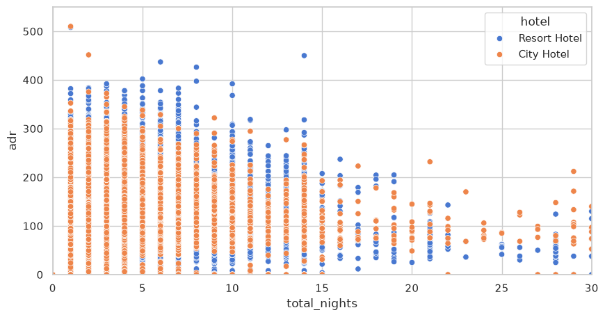

```python
df['total_nights'] = df['stays_in_weekend_nights'] + df['stays_in_week_nights']

plt.figure(figsize=(10, 5))
sns.scatterplot(data=df, x='total_nights', y='adr', hue='hotel')

plt.ylim(0, 550)
plt.xlim(0, 30)
```

1. Como o preço varia com o aumento da duração? o preço diário permanece estável para estadias comuns e reduz levemente em estadias muito longas
2. Existe uma tendência clara? média/fraca, diárias muito caras ocorrem apenas em estadias curtas (1 a 4 noites)
3. Há grande concentração em determinadas durações? sim, entre 1 e 7, com picos fortes entre 1 e 4
4. Existem reservas com duração muito diferente da maioria? sim, algumas estadias de ~15 a mais de 30 noites
5. O comportamento parece diferente entre os hotéis? sim, o city hotel foca em estadias curtas (1-3 noites), enquanto o resort possui mais estadias de 7 e 14 noites

<h1 id="gr%C3%A1fico-9---solicita%C3%A7%C3%B5es-especiais-por-perfil-de-cliente">gráfico 9 - solicitações especiais por perfil de cliente</h1>

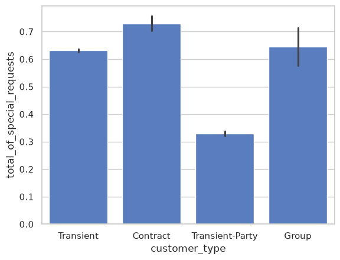

```python
sns.barplot(
    data=df,
    x="customer_type",
    y="total_of_special_requests",
)
```

1. Qual tipo de cliente apresenta maior média? contract
2. Qual apresenta menor média?<br /> transient-party
3. As diferenças entre os grupos parecem relevantes? sim, clientes contract fazem quase o dobro de pedidos especiais quando comparados a transient-party
4. Que interpretação de negócio poderia ser levantada a partir desse padrão? o hotel deve priorizar o atendimento prévio das solicitações dos clientes contract, pois atender a essas preferências é bom para manter contratos corporativos valiosos e garantir a fidelidade desses hóspedes

<h1 id="5-investigacao-de-outliers">5 investigacao de outliers</h1>

```python
def outliers_iqr(col):
    Q1 = df[col].quantile(0.25)
    Q3 = df[col].quantile(0.75)
    IQR = Q3 - Q1
    lim_inf = Q1 - 15 * IQR
    lim_sup = Q3 + 15 * IQR
    n_out = len(df[(df[col] < lim_inf) | (df[col] > lim_sup)])
    print(f"{col}: Q1={Q1:.2f}, Q3={Q3:.2f}, IQR={IQR:.2f} | Limites: [{lim_inf:.2f}, {lim_sup:.2f}] | Outliers: {n_out} ({n_out/len(df)*100:.2f}%)")

outliers_iqr('adr')
outliers_iqr('lead_time')
```

```
adr: Q1=69.29, Q3=126.00, IQR=56.71 | Limites: [-781.36, 976.65] | Outliers: 1 (0.00%)
lead_time: Q1=18.00, Q3=160.00, IQR=142.00 | Limites: [-2112.00, 2290.00] | Outliers: 0 (0.00%)
```

<h1 id="6-correla%C3%A7%C3%A3o-entre-atributos-num%C3%A9ricos">6 correlação entre atributos numéricos</h1>

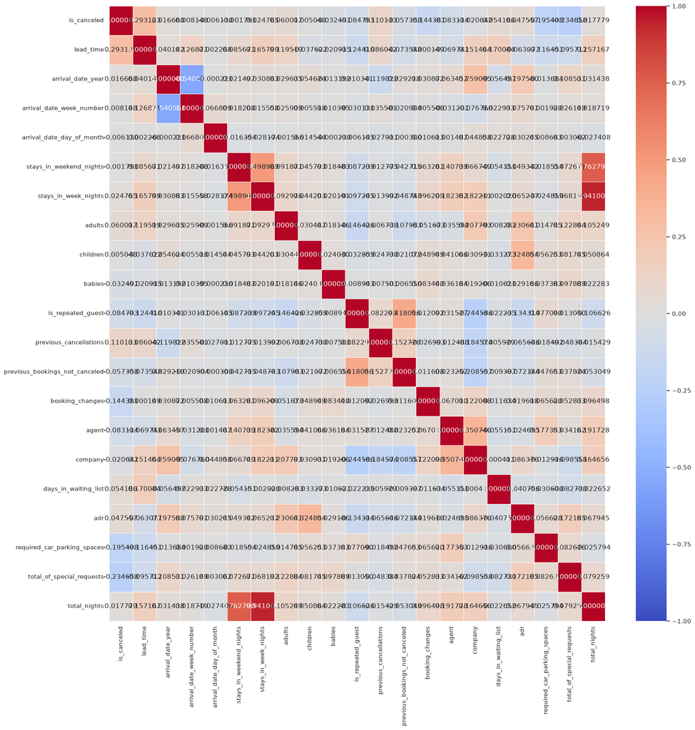

```python
mat = df.corr(numeric_only=True)
plt.figure(figsize=(20,20))
sns.heatmap(mat, annot=True, fmt='2f', cmap='coolwarm', linewidths=0.5, vmin=-1, vmax=1)
```

1. <p>Quais pares apresentam as maiores correlações em módulo?<br /> total_nights com stays_in_week_nights = 0,94 (obviamente) total_nights com stays_in_wekeend_nights = 076 (obviamente)</p>
2. <p>As correlações mais fortes são coerentes com os scatter plots?<br /> foras as triviais, sim, por exemplo o lead_time e is_canceled, adults e adr, etc</p>
3. <p>Existe alguma correlação que possa ser enganosa por causa da natureza do atributo ou do contexto?<br /> sim, as variaveis binárias/categóricas</p>
4. <p>Escolha uma relação que mereceria investigação em uma etapa posterior e explique por quê<br /> a relação entre vagas de estacionamento e cancelamento: clientes que solicitam estacionamento raramente cancelam (-0,20), sendo um possivel preditor de presença confirmada</p>

<h1 id="s%C3%ADntese:-o-que-os-dados-revelam?">síntese: o que os dados revelam?</h1>

<h1 id="Principais-Achados:">Principais Achados:</h1>

<h1 id="3-ideias-para-projetos-futuros-de-mineracao-de-dados:">3 ideias para projetos futuros de mineracao de dados:</h1>

1. <p>Detecção de Fraude e Reservas "Fantasma": Como identificar padrões de reservas falsas ou especulativas, feitas por robôs, agências ou concorrentes que bloqueiam os quartos com muita antecedência e cancelam de última hora para manipular o estoque de preços do hotel?</p>
2. <p>Otimização de Políticas de Cancelamento Dinâmicas: Em vez de apenas prever se o cliente vai cancelar, qual deve ser a taxa de depósito obrigatória ou a política de reembolso ideal personalizada para cada cliente no momento da reserva para minimizar a taxa de desistência sem perder a venda?</p>
3. <p>Previsão de Demanda e Preço Dinâmico: Modelo de séries temporais para prever ocupação e sugerir tarifas ideais por temporada.</p>